# Master en Big Data. Fundamentos Matemáticos del Análisis de Datos (FMAD).

Tarea 1

Departamento de Matemática Aplicada

Curso 2021-22. Última actualización: 2021-09-17

# Instrucciones preliminares

- Empieza abriendo el proyecto de RStudio correspondiente a tu repositorio personal de la asignatura.
- En todas las tareas tendrás que repetir un proceso como el descrito en la sección *Repite los pasos Creando un fichero Rmarkdown para esta práctica* de la *Práctica00*. Puedes releer la sección *Practicando la entrega de las Tareas* de esa misma práctica para recordar el procedimiento de entrega.

# Ejercicio 0

- Si no has hecho los *Ejercicios* de la *Práctica00* (págs. 12 y 13) hazlos ahora y añádelos a esta tarea. Si ya los has hecho y entregado a través de GitHub no hace falta que hagas nada.

# Ejercicio 1. Análisis exploratorio de un conjunto de datos y operaciones con dplyr.

# Preliminares

```r
library(dplyr)
library(ggplot2)
library(tidyverse)
library(haven)
```

- Vamos a utilizar el conjunto de datos contenido en el fichero (es un enlace):  
  cholesterol.csv  
  Los datos proceden de un estudio realizado en la *University of Virginia School of Medicine* que investiga la prevalencia de la obesidad, la diabetes y otros factores de riesgo cardiovascular. Se puede encontrar más información sobre el fichero en este enlace:  
  https://biostat.app.vumc.org/wiki/pub/Main/DataSets/diabetes.html
- Carga el conjunto de datos en un data.frame de R llamado `chlstrl`.
- Empezaremos por información básica sobre el conjunto de datos. Cuántas observaciones contiene, cuáles son las variables y de qué tipos,…

```r
file_url <- "https://gist.githubusercontent.com/fsansegundo/ee991e53e1a571dd34034c42b5516eae/raw/2206455b5772e90c5a2a24a3f42a84408fd1d1c5/cholesterol.csv"

local_folder <-  "./data/"

file_name <- tail(unlist(strsplit(file_url, split = "/")), 1)
localFile <-  paste0(local_folder, file_name)
if(!file.exists(localFile)){
  download.file(url = file_url, destfile = localFile)
} else {
  warning(paste0("Cuidado: el fichero de datos", localFile, " ya existe."))
}
chlstrl <- read_csv("./data/cholesterol.csv")
chlstrl
```

```
## # A tibble: 403 x 7
##     chol   age gender height weight waist   hip
##    <dbl> <dbl> <chr>   <dbl>  <dbl> <dbl> <dbl>
##  1   203    46 female     62    121    29    38
##  2   165    29 female     64    218    46    48
##  3   228    58 female     61    256    49    57
##  4    78    67 male       67    119    33    38
##  5   249    64 male       68    183    44    41
##  6   248    34 male       71    190    36    42
##  7   195    30 male       69    191    46    49
##  8   227    37 male       59    170    34    39
##  9   177    45 male       69    166    34    40
## 10   263    55 female     63    202    45    50
## # ... with 393 more rows
```

- Asegúrate de comprobar si hay datos ausentes y localízalos en la tabla.

Se comprueba si hay valores nulos en la tabla.

```r
any(is.na(chlstrl))
```

```
## [1] TRUE
```

Como el resultado es positivo, es decir, existen valores nulos, es importante conocer cuantos. A la hora de realizar operaciones se tendrá en cuenta que existen valores nulos para omitirlos.

```r
sum(is.na(chlstrl))
```

```
## [1] 11
```

- El análisis exploratorio (numérico y gráfico) debe cubrir todos los tipos de variable de la tabla. Es decir, que al menos debes estudiar una variable por cada tipo de variable presente en la tabla. El análisis debe contener, al menos:
  - Para las variables cuantittativas (continuas o discretas).  
    Resumen numérico básico.  
    Gráficas (las adecuadas, a ser posible más de un tipo de gráfico).
  - Variables categóricas (factores).  
    Tablas de frecuencia (absolutas y relativas).  
    Gráficas (diagrama de barras).

**Análisis de los datos**

Se analizan las variables, a que clase pertenecen y otros valores de interés como la media y la mediana de cada variable.

```r
chlstrl %>%
  sapply(class)
```

```
##        chol         age      gender      height      weight       waist
##   "numeric"   "numeric" "character"   "numeric"   "numeric"   "numeric"
##         hip
##   "numeric"
```

```r
summary(chlstrl, na.rm=TRUE)
```

```
##       chol            age           gender              height
##  Min.   : 78.0   Min.   :19.00   Length:403         Min.   :52.00
##  1st Qu.:179.0   1st Qu.:34.00   Class :character   1st Qu.:63.00
##  Median :204.0   Median :45.00   Mode  :character   Median :66.00
##  Mean   :207.8   Mean   :46.85                      Mean   :66.02
##  3rd Qu.:230.0   3rd Qu.:60.00                      3rd Qu.:69.00
##  Max.   :443.0   Max.   :92.00                      Max.   :76.00
##  NA's   :1                                          NA's   :5
##      weight          waist           hip
##  Min.   : 99.0   Min.   :26.0   Min.   :30.00
##  1st Qu.:151.0   1st Qu.:33.0   1st Qu.:39.00
##  Median :172.5   Median :37.0   Median :42.00
##  Mean   :177.6   Mean   :37.9   Mean   :43.04
##  3rd Qu.:200.0   3rd Qu.:41.0   3rd Qu.:46.00
##  Max.   :325.0   Max.   :56.0   Max.   :64.00
##  NA's   :1       NA's   :2      NA's   :2
```

**Análisis de las variables**

Se representan las funciones de densidad de las variables numéricas y se calculan las frecuncias relativas y absolutas del factor género.

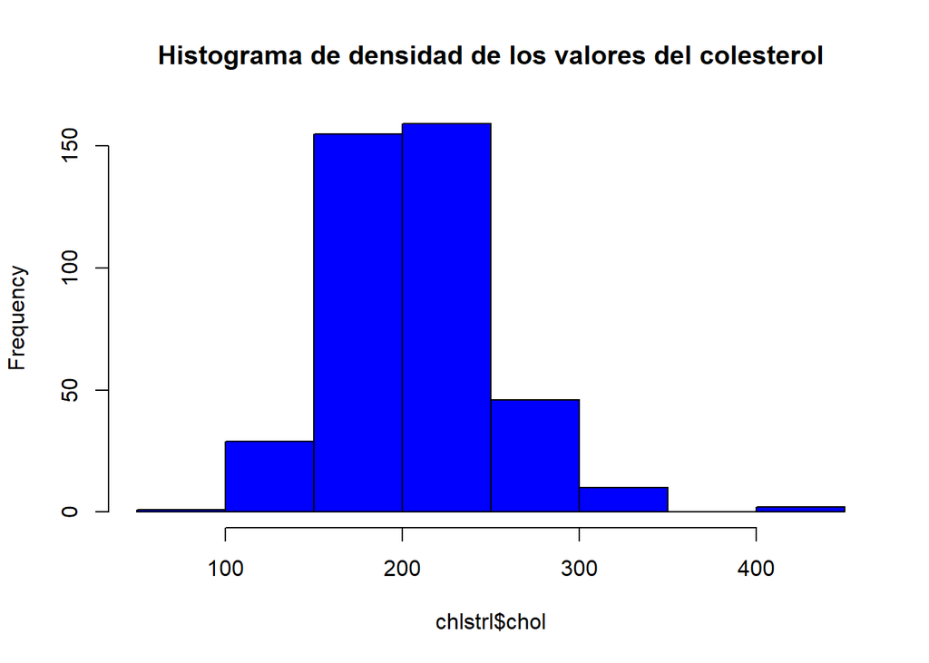

```r
hist(chlstrl$chol, main='Histograma de densidad de los valores del colesterol', col='blue')
```

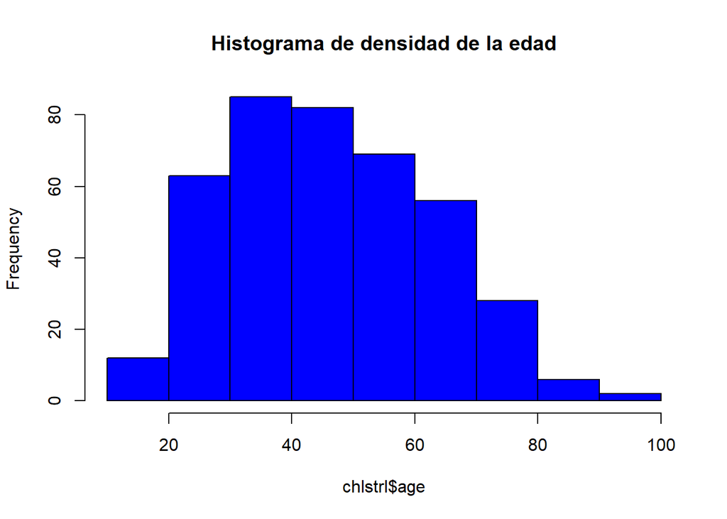

```r
hist(chlstrl$age, main='Histograma de densidad de la edad', col='blue')
```

```r
chlstrl %>%
  count(gender)
```

```
## # A tibble: 2 x 2
##   gender     n
##   <chr>  <int>
## 1 female   234
## 2 male     169
```

```r
signif(prop.table(table(chlstrl$gender)), 2)
```

```
##
## female   male
##   0.58   0.42
```

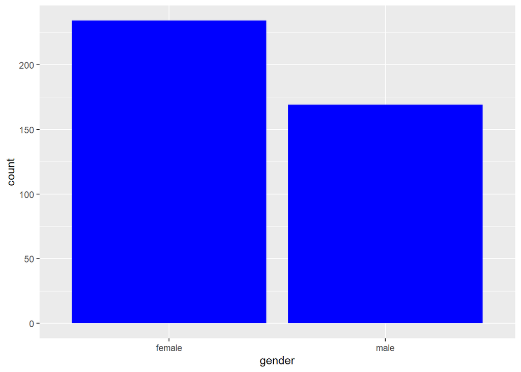

```r
ggplot(chlstrl, aes(gender)) + geom_bar(fill='blue')
```

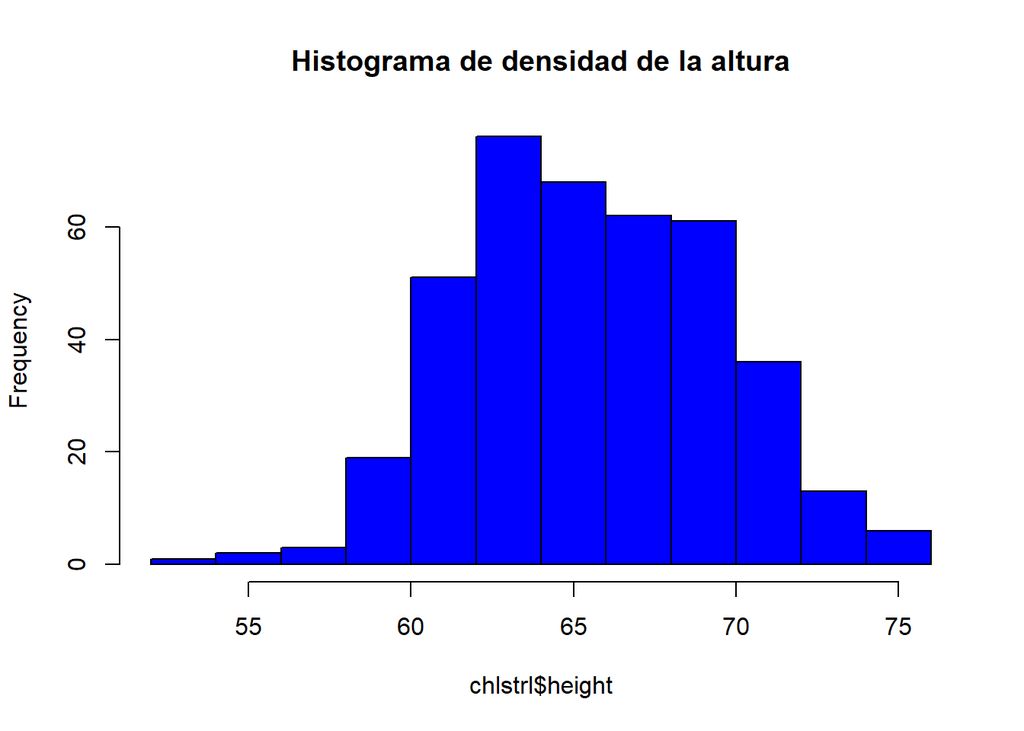

```r
hist(chlstrl$height, main='Histograma de densidad de la altura', col='blue')
```

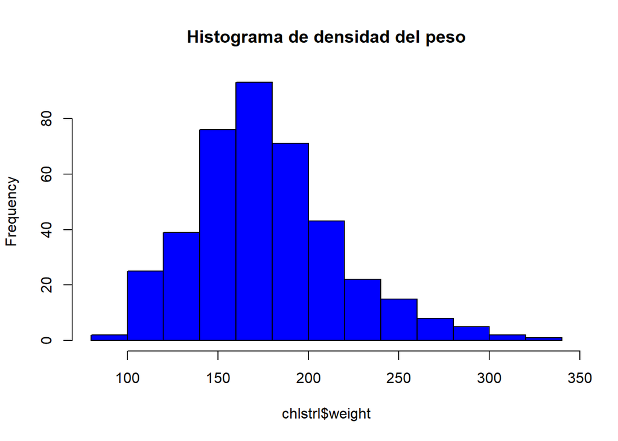

```r
hist(chlstrl$weight, main='Histograma de densidad del peso', col='blue')
```

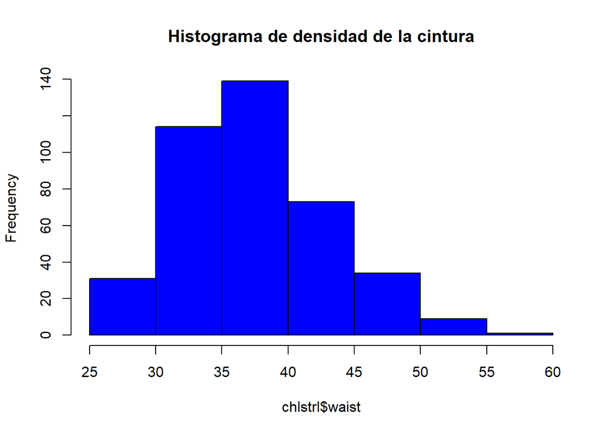

```r
hist(chlstrl$waist, main='Histograma de densidad de la cintura',  col='blue')
```

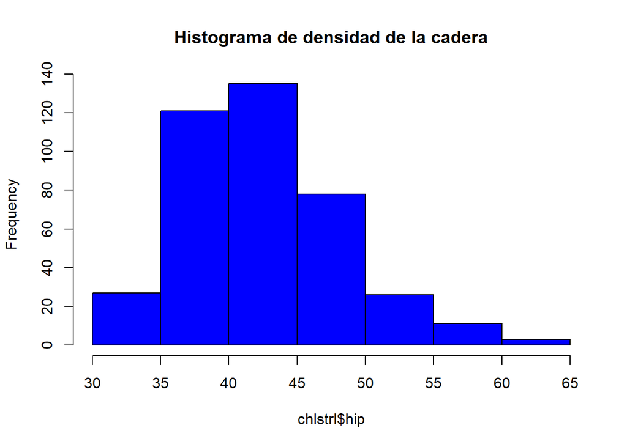

```r
hist(chlstrl$hip, main='Histograma de densidad de la cadera', col='blue')
```

- Los valores de `height` y `weight` están en pulgadas (inches) y libras (pounds) respectivamente. Una libra son $\approx$ 0.454kg y una pulgada son $\approx$ 0.0254m. Usa dplyr para convertir esas columnas a metros y kilogramos respectivamente. Las nuevas columnas deben llamarse igual que las originales.

Se crea una nueva tabla llamada chlstrl1 en la que la altura y el peso vienen representados en metros y kilogramos respectivamente.

```r
chlstrl
```

```
## # A tibble: 403 x 7
##     chol   age gender height weight waist   hip
##    <dbl> <dbl> <chr>   <dbl>  <dbl> <dbl> <dbl>
##  1   203    46 female     62    121    29    38
##  2   165    29 female     64    218    46    48
##  3   228    58 female     61    256    49    57
##  4    78    67 male       67    119    33    38
##  5   249    64 male       68    183    44    41
##  6   248    34 male       71    190    36    42
##  7   195    30 male       69    191    46    49
##  8   227    37 male       59    170    34    39
##  9   177    45 male       69    166    34    40
## 10   263    55 female     63    202    45    50
## # ... with 393 more rows
```

```r
chlstrl1 = chlstrl %>%
  mutate(height=height*0.0254, weight=weight*0.454)
chlstrl1
```

```
## # A tibble: 403 x 7
##     chol   age gender height weight waist   hip
##    <dbl> <dbl> <chr>   <dbl>  <dbl> <dbl> <dbl>
##  1   203    46 female   1.57   54.9    29    38
##  2   165    29 female   1.63   99.0    46    48
##  3   228    58 female   1.55  116.     49    57
##  4    78    67 male     1.70   54.0    33    38
##  5   249    64 male     1.73   83.1    44    41
##  6   248    34 male     1.80   86.3    36    42
##  7   195    30 male     1.75   86.7    46    49
##  8   227    37 male     1.50   77.2    34    39
##  9   177    45 male     1.75   75.4    34    40
## 10   263    55 female   1.60   91.7    45    50
## # ... with 393 more rows
```

- Ahora usa esos valores de `height` y `weight` para añadir una nueva columna llamada BMI, definida mediante:
  $$BMI = \dfrac{weight}{height^2}$$
  Se crea una nueva tabla llamada chlstrl2 en la que se añade una nueva variable, BMI.

```r
chlstrl
```

```
## # A tibble: 403 x 7
##     chol   age gender height weight waist   hip
##    <dbl> <dbl> <chr>   <dbl>  <dbl> <dbl> <dbl>
##  1   203    46 female     62    121    29    38
##  2   165    29 female     64    218    46    48
##  3   228    58 female     61    256    49    57
##  4    78    67 male       67    119    33    38
##  5   249    64 male       68    183    44    41
##  6   248    34 male       71    190    36    42
##  7   195    30 male       69    191    46    49
##  8   227    37 male       59    170    34    39
##  9   177    45 male       69    166    34    40
## 10   263    55 female     63    202    45    50
## # ... with 393 more rows
```

```r
chlstrl2 = chlstrl1 %>%
  mutate(BMI=weight/(height^2))
chlstrl2
```

```
## # A tibble: 403 x 8
##     chol   age gender height weight waist   hip   BMI
##    <dbl> <dbl> <chr>   <dbl>  <dbl> <dbl> <dbl> <dbl>
##  1   203    46 female   1.57   54.9    29    38  22.2
##  2   165    29 female   1.63   99.0    46    48  37.5
##  3   228    58 female   1.55  116.     49    57  48.4
##  4    78    67 male     1.70   54.0    33    38  18.7
##  5   249    64 male     1.73   83.1    44    41  27.8
##  6   248    34 male     1.80   86.3    36    42  26.5
##  7   195    30 male     1.75   86.7    46    49  28.2
##  8   227    37 male     1.50   77.2    34    39  34.4
##  9   177    45 male     1.75   75.4    34    40  24.5
## 10   263    55 female   1.60   91.7    45    50  35.8
## # ... with 393 more rows
```

```r
chlstrl3 = chlstrl2 %>%
  mutate(ageGroup=cut(age, breaks = c(10,40,70,100)))
chlstrl3
```

```
## # A tibble: 403 x 9
##     chol   age gender height weight waist   hip   BMI ageGroup
##    <dbl> <dbl> <chr>   <dbl>  <dbl> <dbl> <dbl> <dbl> <fct>
##  1   203    46 female   1.57   54.9    29    38  22.2 (40,70]
##  2   165    29 female   1.63   99.0    46    48  37.5 (10,40]
##  3   228    58 female   1.55  116.     49    57  48.4 (40,70]
##  4    78    67 male     1.70   54.0    33    38  18.7 (40,70]
##  5   249    64 male     1.73   83.1    44    41  27.8 (40,70]
##  6   248    34 male     1.80   86.3    36    42  26.5 (10,40]
##  7   195    30 male     1.75   86.7    46    49  28.2 (10,40]
##  8   227    37 male     1.50   77.2    34    39  34.4 (10,40]
##  9   177    45 male     1.75   75.4    34    40  24.5 (40,70]
## 10   263    55 female   1.60   91.7    45    50  35.8 (40,70]
## # ... with 393 more rows
```

- Usando `dplyr` calcula cuántas observaciones hay en cada nivel de `ageGroup` (indicación: usa `group_by`). Ahora, usando aquellas observaciones que corresponden a mujeres, ¿cuál es la media del nivel de colesterol y de BMI en cada uno de esos grupos de edad?

```r
chlstrl3 %>%
  filter(gender=='female') %>%
  group_by(ageGroup) %>%
  summarise(media=mean(chol, na.rm=TRUE))
```

```
## # A tibble: 3 x 2
##   ageGroup media
##   <fct>    <dbl>
## 1 (10,40]   189.
## 2 (40,70]   221.
## 3 (70,100]  230.
```

# Ejercicio 2: Funciones de R.

- Crea una función de R llamada `cambiosSigno` que dado un vector `x` de números enteros no nulos, como

  ```
  -12,  -19,  9,  -13,  -14,  -17,  8,  -19,  -14,
  ```

  calcule cuántos cambios de signo ha habido. Es decir, cuántas veces el signo de un elemento es distinto del signo del elemento previo. Por ejemplo, en el vector anterior hay 4 cambios de signo (en las posiciones 3, 4, 7 y 8).

```r
cambiosSigno=function(x){
  n=0
  for (i in 1:(length(x)-1)){
    if (sign(x[i+1])!=sign(x[i])){
      n=n+1
    }
  }
  print(n)
}
cambiosSigno(x)
```

```
## [1] 4
```

- Modifica la función para que devuelva como resultado las posiciones donde hay cambios de signo. Llama `cambiosSignoPos(x)` a esa otra función. Por ejemplo, para el vector anterior el resultado de esta función sería [1] 3 4 7 8

```r
cambiosSignoPos=function(x){
  m=c()
  for (i in 1:(length(x)-1)){
    if (sign(x[i+1])!=sign(x[i])){
      m=append(m,i+1)
    }
  }
  print(m)
}
cambiosSignoPos(x)
```

```
## [1] 3 4 7 8
```

[output not shown]